# Project: Investigate TMDB movies dataset

- Introduction
- Data Wrangling
- Exploratory Data Analysis
- Conclusions

## Introduction

### Dataset Description

This data set contains information about 10,000 movies collected from The Movie Database (TMDb), including user ratings and revenue.

- Certain columns, like ‘cast’ and ‘genres’, contain multiple values separated by pipe (|) characters.
- The final two columns ending with “_adj” show the budget and revenue of the associated movie in terms of 2010 dollars, accounting for inflation over time.

```python
#Importing packages used for analysing and plotting data
import numpy as np
import pandas as pd
import csv
import matplotlib.pyplot as plt
import seaborn as sns

%matplotlib inline
```

## Data Wrangling

### General Properties

```python
# Load data set
df = pd.read_csv("tmdb-movies.csv")
```

```python
df.head(2)
```

|  | id | imdb_id | popularity | budget | revenue | original_title | cast | homepage | director | tagline | ... | overview | runtime | genres | production_companies | release_date | vote_count | vote_average | release_year | budget_adj | revenue_adj |
| --- | --- | --- | --- | --- | --- | --- | --- | --- | --- | --- | --- | --- | --- | --- | --- | --- | --- | --- | --- | --- | --- |
| 0 | 135397 | tt0369610 | 32.985763 | 150000000 | 1513528810 | Jurassic World | Chris Pratt\|Bryce Dallas Howard\|Irrfan Khan\|Vi... | http://www.jurassicworld.com/ | Colin Trevorrow | The park is open. | ... | Twenty-two years after the events of Jurassic ... | 124 | Action\|Adventure\|Science Fiction\|Thriller | Universal Studios\|Amblin Entertainment\|Legenda... | 6/9/15 | 5562 | 6.5 | 2015 | 1.379999e+08 | 1.392446e+09 |
| 1 | 76341 | tt1392190 | 28.419936 | 150000000 | 378436354 | Mad Max: Fury Road | Tom Hardy\|Charlize Theron\|Hugh Keays-Byrne\|Nic... | http://www.madmaxmovie.com/ | George Miller | What a Lovely Day. | ... | An apocalyptic story set in the furthest reach... | 120 | Action\|Adventure\|Science Fiction\|Thriller | Village Roadshow Pictures\|Kennedy Miller Produ... | 5/13/15 | 6185 | 7.1 | 2015 | 1.379999e+08 | 3.481613e+08 |

2 rows × 21 columns

COLUMN DESCRIPTION id ....................movie id imdb_id ...............imdb id popularity ............popularity rating score budget ................amount budget for the movie revenue ...............revenue generated from the movie original_title ........movie title cast ..................movie cast separated with "|" homepage ..............website of the movie director ..............name of movie director tagline ...............movie tagline keywords ..............movie search keywords overview ..............brief overview of the movie runtime ...............movie duration in minutes genres ................genre categories the movie falls separated with "|" production_companies ..production companies separated with "|" release_date ..........movie release date vote_count ............vote count for the movie release_year ..........movie release year budget_adj ............movie budget in terms of 2010 dollars, accounting for inflation over time. revenue_adj ...........movie revenue in terms of 2010 dollars, accounting for inflation over time.

```python
df.shape
```

```
(10866, 21)
```

This data set contains information over 10,866 movies with 21 columns collected from The Movie Database (TMDb), including user ratings, budget and revenue generated from the movie.

```python
df.describe()
```

|  | id | popularity | budget | revenue | runtime | vote_count | vote_average | release_year | budget_adj | revenue_adj |
| --- | --- | --- | --- | --- | --- | --- | --- | --- | --- | --- |
| count | 10866.000000 | 10866.000000 | 1.086600e+04 | 1.086600e+04 | 10866.000000 | 10866.000000 | 10866.000000 | 10866.000000 | 1.086600e+04 | 1.086600e+04 |
| mean | 66064.177434 | 0.646441 | 1.462570e+07 | 3.982332e+07 | 102.070863 | 217.389748 | 5.974922 | 2001.322658 | 1.755104e+07 | 5.136436e+07 |
| std | 92130.136561 | 1.000185 | 3.091321e+07 | 1.170035e+08 | 31.381405 | 575.619058 | 0.935142 | 12.812941 | 3.430616e+07 | 1.446325e+08 |
| min | 5.000000 | 0.000065 | 0.000000e+00 | 0.000000e+00 | 0.000000 | 10.000000 | 1.500000 | 1960.000000 | 0.000000e+00 | 0.000000e+00 |
| 25% | 10596.250000 | 0.207583 | 0.000000e+00 | 0.000000e+00 | 90.000000 | 17.000000 | 5.400000 | 1995.000000 | 0.000000e+00 | 0.000000e+00 |
| 50% | 20669.000000 | 0.383856 | 0.000000e+00 | 0.000000e+00 | 99.000000 | 38.000000 | 6.000000 | 2006.000000 | 0.000000e+00 | 0.000000e+00 |
| 75% | 75610.000000 | 0.713817 | 1.500000e+07 | 2.400000e+07 | 111.000000 | 145.750000 | 6.600000 | 2011.000000 | 2.085325e+07 | 3.369710e+07 |
| max | 417859.000000 | 32.985763 | 4.250000e+08 | 2.781506e+09 | 900.000000 | 9767.000000 | 9.200000 | 2015.000000 | 4.250000e+08 | 2.827124e+09 |

```python
df.info()
```

```
<class 'pandas.core.frame.DataFrame'>
RangeIndex: 10866 entries, 0 to 10865
Data columns (total 21 columns):
id                      10866 non-null int64
imdb_id                 10856 non-null object
popularity              10866 non-null float64
budget                  10866 non-null int64
revenue                 10866 non-null int64
original_title          10866 non-null object
cast                    10790 non-null object
homepage                2936 non-null object
director                10822 non-null object
tagline                 8042 non-null object
keywords                9373 non-null object
overview                10862 non-null object
runtime                 10866 non-null int64
genres                  10843 non-null object
production_companies    9836 non-null object
release_date            10866 non-null object
vote_count              10866 non-null int64
vote_average            10866 non-null float64
release_year            10866 non-null int64
budget_adj              10866 non-null float64
revenue_adj             10866 non-null float64
dtypes: float64(4), int64(6), object(11)
memory usage: 1.7+ MB
```

```python
# Examine columns with missing values
df.isnull().sum()
```

```
id                         0
imdb_id                   10
popularity                 0
budget                     0
revenue                    0
original_title             0
cast                      76
homepage                7930
director                  44
tagline                 2824
keywords                1493
overview                   4
runtime                    0
genres                    23
production_companies    1030
release_date               0
vote_count                 0
vote_average               0
release_year               0
budget_adj                 0
revenue_adj                0
dtype: int64
```

We have some columns with missing values. We would drop unsused columns

```python
# Create a duplicated copy
df.drop(['id','imdb_id','cast','homepage','director','tagline','keywords','overview','genres',
             'production_companies','release_date','budget_adj','revenue_adj'],
            axis = 1, inplace = True)
df.head()
```

|  | popularity | budget | revenue | original_title | runtime | vote_count | vote_average | release_year |
| --- | --- | --- | --- | --- | --- | --- | --- | --- |
| 0 | 32.985763 | 150000000 | 1513528810 | Jurassic World | 124 | 5562 | 6.5 | 2015 |
| 1 | 28.419936 | 150000000 | 378436354 | Mad Max: Fury Road | 120 | 6185 | 7.1 | 2015 |
| 2 | 13.112507 | 110000000 | 295238201 | Insurgent | 119 | 2480 | 6.3 | 2015 |
| 3 | 11.173104 | 200000000 | 2068178225 | Star Wars: The Force Awakens | 136 | 5292 | 7.5 | 2015 |
| 4 | 9.335014 | 190000000 | 1506249360 | Furious 7 | 137 | 2947 | 7.3 | 2015 |

```python
df.info()
```

```
<class 'pandas.core.frame.DataFrame'>
RangeIndex: 10866 entries, 0 to 10865
Data columns (total 8 columns):
popularity        10866 non-null float64
budget            10866 non-null int64
revenue           10866 non-null int64
original_title    10866 non-null object
runtime           10866 non-null int64
vote_count        10866 non-null int64
vote_average      10866 non-null float64
release_year      10866 non-null int64
dtypes: float64(2), int64(5), object(1)
memory usage: 679.2+ KB
```

```python
df.shape
```

```
(10866, 8)
```

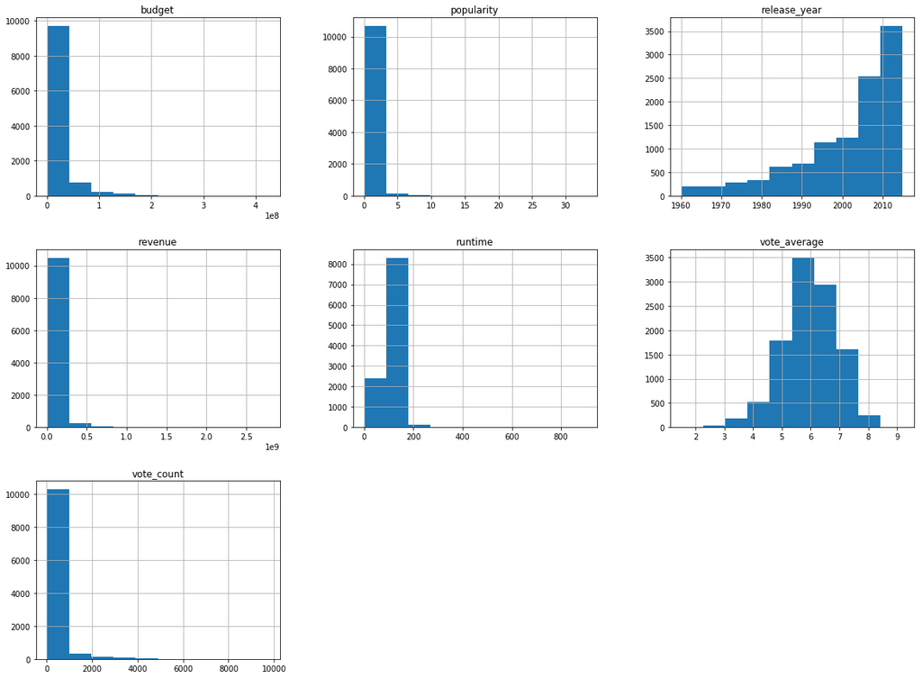

```python
df.hist(figsize=(20,15));
```

- Most movie budget was less than 50 Million
- Most popularity vote is less than 3
- Most movies were released after year 2000
- The revenue generated from most movies is less than 300 Million
- The runtime for most movies is less than 200 mins
- The average vote_average is between 5-7
- Most movies got a vote count of less than 1,000

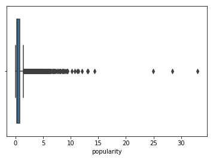

```python
sns.boxplot(x=df['popularity'])
```

```python
#Check the 3 extreme values
df[df.popularity > 20]
```

|  | popularity | budget | revenue | original_title | runtime | vote_count | vote_average | release_year |
| --- | --- | --- | --- | --- | --- | --- | --- | --- |
| 0 | 32.985763 | 150000000 | 1513528810 | Jurassic World | 124 | 5562 | 6.5 | 2015 |
| 1 | 28.419936 | 150000000 | 378436354 | Mad Max: Fury Road | 120 | 6185 | 7.1 | 2015 |
| 629 | 24.949134 | 165000000 | 621752480 | Interstellar | 169 | 6498 | 8.0 | 2014 |

**Let do a deep dive into the 3 dataset with outrageous values far greater than the average.**

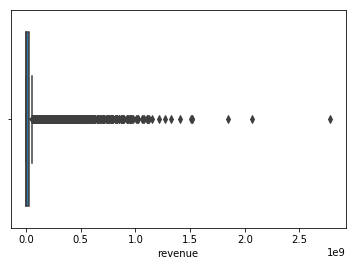

```python
sns.boxplot(x=df['revenue'])
```

```python
#Create a container for these 3 values using popularity column
df[df.revenue > 1800000000]
```

|  | popularity | budget | revenue | original_title | runtime | vote_count | vote_average | release_year |
| --- | --- | --- | --- | --- | --- | --- | --- | --- |
| 3 | 11.173104 | 200000000 | 2068178225 | Star Wars: The Force Awakens | 136 | 5292 | 7.5 | 2015 |
| 1386 | 9.432768 | 237000000 | 2781505847 | Avatar | 162 | 8458 | 7.1 | 2009 |
| 5231 | 4.355219 | 200000000 | 1845034188 | Titanic | 194 | 4654 | 7.3 | 1997 |

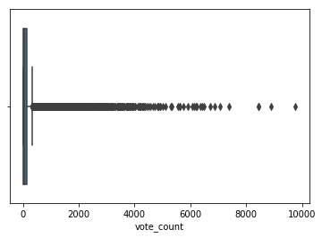

```python
sns.boxplot(x=df['vote_count'])
```

```python
#Create a container for these 3 values using popularity column
df[df.vote_count > 8000]
```

|  | popularity | budget | revenue | original_title | runtime | vote_count | vote_average | release_year |
| --- | --- | --- | --- | --- | --- | --- | --- | --- |
| 1386 | 9.432768 | 237000000 | 2781505847 | Avatar | 162 | 8458 | 7.1 | 2009 |
| 1919 | 9.363643 | 160000000 | 825500000 | Inception | 148 | 9767 | 7.9 | 2010 |
| 2875 | 8.466668 | 185000000 | 1001921825 | The Dark Knight | 152 | 8432 | 8.1 | 2008 |
| 4361 | 7.637767 | 220000000 | 1519557910 | The Avengers | 143 | 8903 | 7.3 | 2012 |

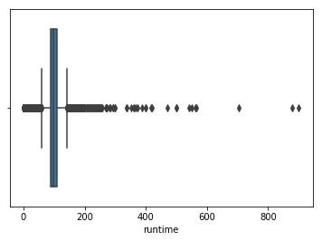

```python
sns.boxplot(x=df['runtime'])
```

```python
#Create a container for these 3 values using popularity column
df[df.runtime > 600]
```

|  | popularity | budget | revenue | original_title | runtime | vote_count | vote_average | release_year |
| --- | --- | --- | --- | --- | --- | --- | --- | --- |
| 2722 | 0.537593 | 0 | 125000000 | Band of Brothers | 705 | 313 | 8.0 | 2001 |
| 3894 | 0.006925 | 0 | 0 | The Story of Film: An Odyssey | 900 | 14 | 9.2 | 2011 |
| 4041 | 0.469332 | 0 | 0 | Taken | 877 | 38 | 6.8 | 2002 |

**What movie detail has the highest popularity?**

```python
df[df.popularity == df.popularity.max()]
```

|  | popularity | budget | revenue | original_title | runtime | vote_count | vote_average | release_year |
| --- | --- | --- | --- | --- | --- | --- | --- | --- |
| 0 | 32.985763 | 150000000 | 1513528810 | Jurassic World | 124 | 5562 | 6.5 | 2015 |

**What movie detail has the highest budget?**

```python
df[df.budget == df.budget.max()]
```

|  | popularity | budget | revenue | original_title | runtime | vote_count | vote_average | release_year |
| --- | --- | --- | --- | --- | --- | --- | --- | --- |
| 2244 | 0.25054 | 425000000 | 11087569 | The Warrior's Way | 100 | 74 | 6.4 | 2010 |

**What movie detail generated the highest revenue?**

```python
df[df.revenue == df.revenue.max()]
```

|  | popularity | budget | revenue | original_title | runtime | vote_count | vote_average | release_year |
| --- | --- | --- | --- | --- | --- | --- | --- | --- |
| 1386 | 9.432768 | 237000000 | 2781505847 | Avatar | 162 | 8458 | 7.1 | 2009 |

**What movie detail has the longest runtime?**

```python
df[df.runtime == df.runtime.max()]
```

|  | popularity | budget | revenue | original_title | runtime | vote_count | vote_average | release_year |
| --- | --- | --- | --- | --- | --- | --- | --- | --- |
| 3894 | 0.006925 | 0 | 0 | The Story of Film: An Odyssey | 900 | 14 | 9.2 | 2011 |

## Cleaning the data set

It is observed that we have budget and revenue field for some movies to be '0'. This missing rows are quite large and account for 65% of our data set. We need to replace them with a value.

We would see if there is an observable pattern of release_year vs budget and revenue. If there is any we would divide the year into obserbable patterns were possible

```python
df[(df.budget==0) | (df.revenue==0)].count()
```

```
popularity        7011
budget            7011
revenue           7011
original_title    7011
runtime           7011
vote_count        7011
vote_average      7011
release_year      7011
dtype: int64
```

```python
#We would check the percentage of movies that had no budget or no revenue data
(df[(df.budget==0) | (df.revenue==0)].count()/df.count()) * 100
```

```
popularity        64.522363
budget            64.522363
revenue           64.522363
original_title    64.522363
runtime           64.522363
vote_count        64.522363
vote_average      64.522363
release_year      64.522363
dtype: float64
```

We have about 7000 rows with either missing budget or revenue value. This accounted for about 65% of our data set. We would replace the '0'Budget and Revenue with the mean

```python
df['budget'].replace(0,df['budget'].mean(axis=0),inplace=True)
df[(df.budget==0)]
```

|  | popularity | budget | revenue | original_title | runtime | vote_count | vote_average | release_year |
| --- | --- | --- | --- | --- | --- | --- | --- | --- |

```python
df['revenue'].replace(0,df['revenue'].mean(axis=0),inplace=True)
df[(df.revenue==0)]
```

|  | popularity | budget | revenue | original_title | runtime | vote_count | vote_average | release_year |
| --- | --- | --- | --- | --- | --- | --- | --- | --- |

Introduce a new column for Profit

```python
#Profit = Revenue - Budget
#Insert Profit column after the last column
df.insert(3,'profit',df['revenue']-df['budget'])
df.head(3)
```

|  | popularity | budget | revenue | profit | original_title | runtime | vote_count | vote_average | release_year |
| --- | --- | --- | --- | --- | --- | --- | --- | --- | --- |
| 0 | 32.985763 | 150000000.0 | 1.513529e+09 | 1.363529e+09 | Jurassic World | 124 | 5562 | 6.5 | 2015 |
| 1 | 28.419936 | 150000000.0 | 3.784364e+08 | 2.284364e+08 | Mad Max: Fury Road | 120 | 6185 | 7.1 | 2015 |
| 2 | 13.112507 | 110000000.0 | 2.952382e+08 | 1.852382e+08 | Insurgent | 119 | 2480 | 6.3 | 2015 |

## Exploratory Data Analysis

### Research Question 1: Which features of the dataset change show correlation?

To show this, a Correlation Analysis would be conducted. Correlation Analysis is statistical method that is used to discover if there is a relationship between two variables/datasets, and how strong that relationship may be. 0.8 < Corr < 1.0 (Strong Positive Corr) 0.5 < Corr < 0.8 (Moderate Positive Corr) 0 < Corr < 0.5 (Weak Positive Corr) Corr = 0 (No Corr) -0.5 < Corr < 0 (Weak Negative Corr) -0.8 < Corr < -0.5 (Moderate Negative Corr) -1.0 < Corr < -0.8 (Strong Negative Corr)

```python
#Evaluate correlation
df.corr()
```

|  | popularity | budget | revenue | profit | runtime | vote_count | vote_average | release_year |
| --- | --- | --- | --- | --- | --- | --- | --- | --- |
| popularity | 1.000000 | 0.516041 | 0.635285 | 0.600401 | 0.139033 | 0.800828 | 0.209511 | 0.089801 |
| budget | 0.516041 | 1.000000 | 0.705436 | 0.538634 | 0.171329 | 0.615694 | 0.074210 | 0.129290 |
| revenue | 0.635285 | 0.705436 | 1.000000 | 0.977142 | 0.141541 | 0.772942 | 0.152097 | 0.065134 |
| profit | 0.600401 | 0.538634 | 0.977142 | 1.000000 | 0.116865 | 0.734148 | 0.158544 | 0.038647 |
| runtime | 0.139033 | 0.171329 | 0.141541 | 0.116865 | 1.000000 | 0.163278 | 0.156835 | -0.117204 |
| vote_count | 0.800828 | 0.615694 | 0.772942 | 0.734148 | 0.163278 | 1.000000 | 0.253823 | 0.107948 |
| vote_average | 0.209511 | 0.074210 | 0.152097 | 0.158544 | 0.156835 | 0.253823 | 1.000000 | -0.117632 |
| release_year | 0.089801 | 0.129290 | 0.065134 | 0.038647 | -0.117204 | 0.107948 | -0.117632 | 1.000000 |

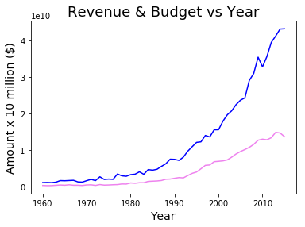

```python
#Plot revenue & budget vs Year to show trend of yearly cashflow
df.groupby('release_year').budget.sum().plot(kind='line', color='violet')
df.groupby('release_year').revenue.sum().plot(kind='line', color='blue')
plt.rcParams["figure.figsize"] = (8,8)
plt.xlabel('Year', fontsize=14)
plt.ylabel('Amount x 10 million ($)', fontsize=14)
plt.title('Revenue & Budget vs Year', fontsize=18)
plt.show()
```

**There is a regular trend with dataset according to release_year. We would divide the time series into 3 categories**

1. Early: Year less than 1980 (This trend shows almost horizontal line)
2. Mid: 2000 < Year > 1980 (This trend shows a gradual increment)
3. Latest: Year > 2000 (This trend shows a very steep increment)

```python
period = []
for row in df['release_year']:
    if row < 1980 : period.append('Earliest(1960-1979)')
    elif row < 2000: period.append('Middle(1980-2000)')
    elif row <= 2015:  period.append('Newest(2000-2015)')
    else:  period.append('Not_Rated')
```

```python
df['period'] = period
```

```python
df.head(3)
```

|  | popularity | budget | revenue | profit | original_title | runtime | vote_count | vote_average | release_year | period |
| --- | --- | --- | --- | --- | --- | --- | --- | --- | --- | --- |
| 0 | 32.985763 | 150000000.0 | 1.513529e+09 | 1.363529e+09 | Jurassic World | 124 | 5562 | 6.5 | 2015 | Newest(2000-2015) |
| 1 | 28.419936 | 150000000.0 | 3.784364e+08 | 2.284364e+08 | Mad Max: Fury Road | 120 | 6185 | 7.1 | 2015 | Newest(2000-2015) |
| 2 | 13.112507 | 110000000.0 | 2.952382e+08 | 1.852382e+08 | Insurgent | 119 | 2480 | 6.3 | 2015 | Newest(2000-2015) |

```python
df['budget'] = df['budget'].replace(0, 14624286.0643)
```

```python
df['budget'].replace(0,df['budget'].mean(axis=0),inplace=True)
df[(df.budget==0)]
```

|  | popularity | budget | revenue | profit | original_title | runtime | vote_count | vote_average | release_year | period |
| --- | --- | --- | --- | --- | --- | --- | --- | --- | --- | --- |

```python
df.head()
```

|  | popularity | budget | revenue | profit | original_title | runtime | vote_count | vote_average | release_year | period |
| --- | --- | --- | --- | --- | --- | --- | --- | --- | --- | --- |
| 0 | 32.985763 | 150000000.0 | 1.513529e+09 | 1.363529e+09 | Jurassic World | 124 | 5562 | 6.5 | 2015 | Newest(2000-2015) |
| 1 | 28.419936 | 150000000.0 | 3.784364e+08 | 2.284364e+08 | Mad Max: Fury Road | 120 | 6185 | 7.1 | 2015 | Newest(2000-2015) |
| 2 | 13.112507 | 110000000.0 | 2.952382e+08 | 1.852382e+08 | Insurgent | 119 | 2480 | 6.3 | 2015 | Newest(2000-2015) |
| 3 | 11.173104 | 200000000.0 | 2.068178e+09 | 1.868178e+09 | Star Wars: The Force Awakens | 136 | 5292 | 7.5 | 2015 | Newest(2000-2015) |
| 4 | 9.335014 | 190000000.0 | 1.506249e+09 | 1.316249e+09 | Furious 7 | 137 | 2947 | 7.3 | 2015 | Newest(2000-2015) |

### Research Question 2 : What is the trend of Budget Spent & Revenue Generated yearly?

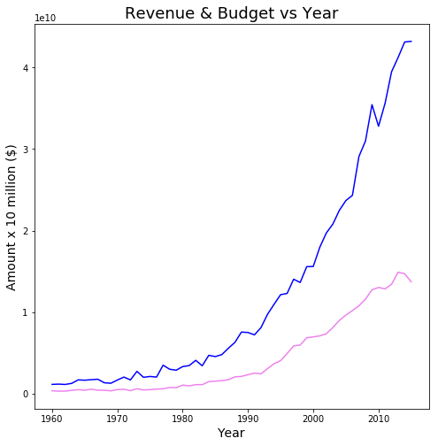

```python
#Plot revenue & budget vs Year to show trend of yearly cashflow
df.groupby('release_year').budget.sum().plot(kind='line', color='violet')
df.groupby('release_year').revenue.sum().plot(kind='line', color='blue')
plt.rcParams["figure.figsize"] = (8,8)
plt.xlabel('Year', fontsize=14)
plt.ylabel('Amount x 10 million ($)', fontsize=14)
plt.title('Revenue & Budget vs Year', fontsize=18)
plt.show()
```

### Research Question 3 : What is the trend of Profit Generated yearly?

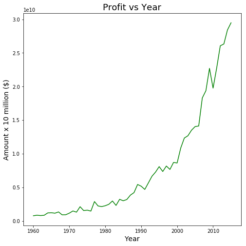

```python
#Plot Profit vs Year to show trend of yearly cashflow
df.groupby('release_year').profit.sum().plot(kind='line', color='green')
plt.rcParams["figure.figsize"] = (8,8)
plt.xlabel('Year', fontsize=14)
plt.ylabel('Amount x 10 million ($)', fontsize=14)
plt.title('Profit vs Year', fontsize=18)
plt.show()
```

### Research Question 4: What is the Popularity Trend of movies over the years?

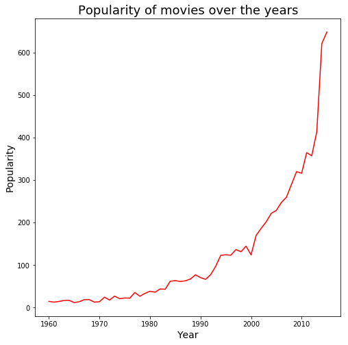

```python
#Plot Profit vs Year to show trend of yearly cashflow
df.groupby('release_year').popularity.sum().plot(kind='line', color='red')
plt.rcParams["figure.figsize"] = (8,8)
plt.xlabel('Year', fontsize=14)
plt.ylabel('Popularity', fontsize=14)
plt.title('Popularity of movies over the years', fontsize=18)
plt.show()
```

### Research Question 5: What is the Runtime Trend of movies over the years?

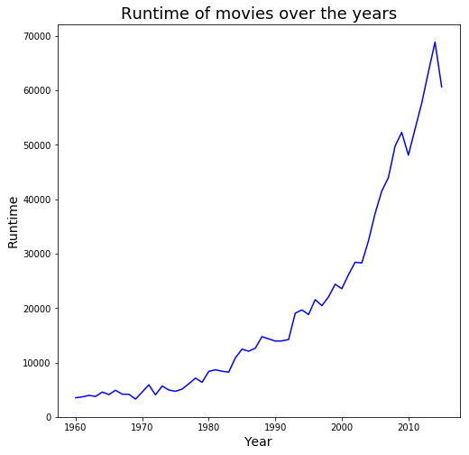

```python
#Plot Profit vs Year to show trend of yearly cashflow
df.groupby('release_year').runtime.sum().plot(kind='line', color='blue')
plt.rcParams["figure.figsize"] = (8,8)
plt.xlabel('Year', fontsize=14)
plt.ylabel('Runtime', fontsize=14)
plt.title('Runtime of movies over the years', fontsize=18)
plt.show()
```

```python
df.head(2)
```

|  | popularity | budget | revenue | profit | original_title | runtime | vote_count | vote_average | release_year | period |
| --- | --- | --- | --- | --- | --- | --- | --- | --- | --- | --- |
| 0 | 32.985763 | 150000000.0 | 1.513529e+09 | 1.363529e+09 | Jurassic World | 124 | 5562 | 6.5 | 2015 | Newest(2000-2015) |
| 1 | 28.419936 | 150000000.0 | 3.784364e+08 | 2.284364e+08 | Mad Max: Fury Road | 120 | 6185 | 7.1 | 2015 | Newest(2000-2015) |

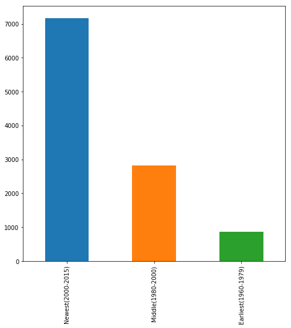

```python
df.period.value_counts().plot(kind='bar')
```

### With Popularity

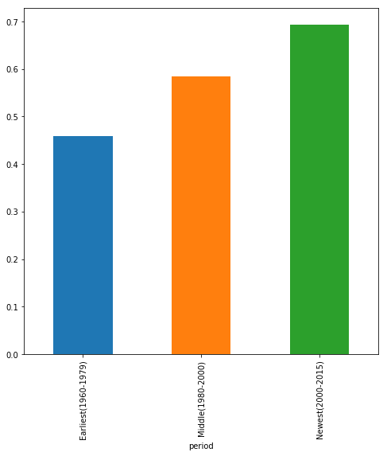

```python
df.groupby('period').popularity.mean().plot(kind= 'bar')
```

### With Runtime

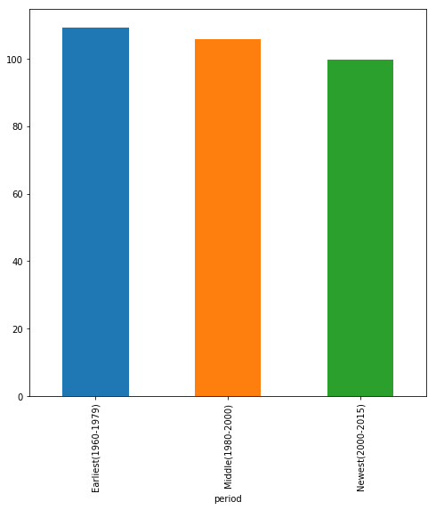

```python
df.groupby('period').runtime.mean().plot(kind= 'bar')
```

### With Vote_count

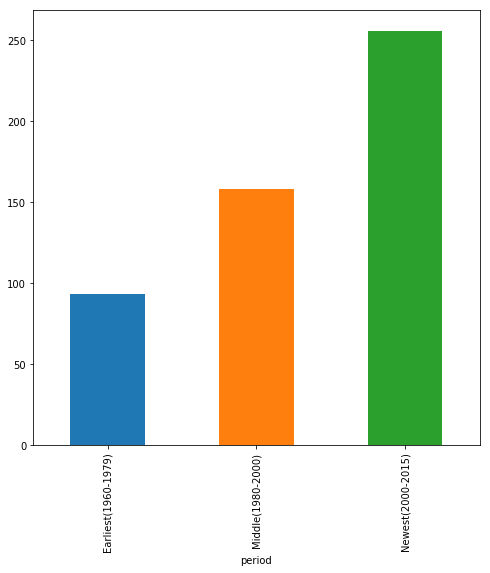

```python
df.groupby('period').vote_count.mean().plot(kind= 'bar')
```

### With Vote Average

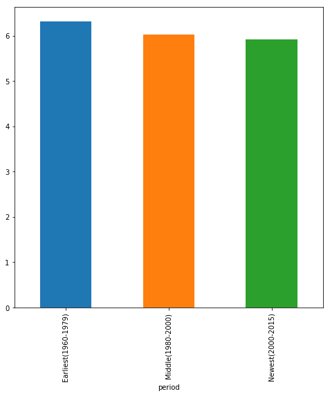

```python
df.groupby('period').vote_average.mean().plot(kind= 'bar')
```

### With Budget

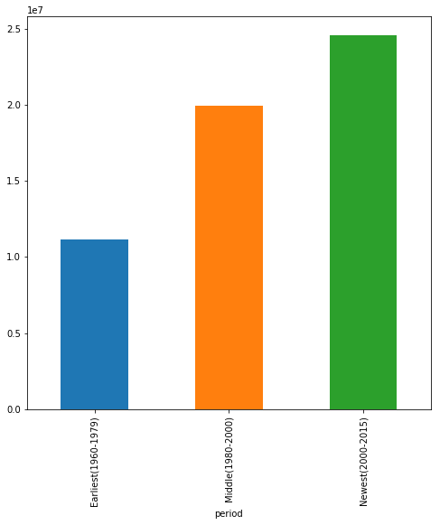

```python
df.groupby('period').budget.mean().plot(kind= 'bar')
```

### With Revenue

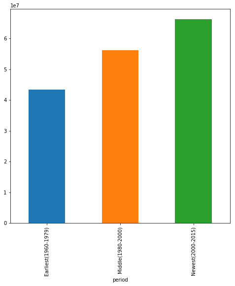

```python
df.groupby('period').revenue.mean().plot(kind= 'bar')
```

### With Profit

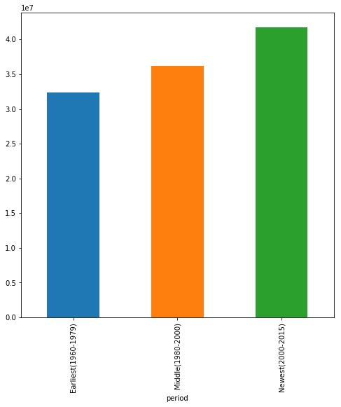

```python
df.groupby('period').profit.mean().plot(kind= 'bar')
```

## Conclusions

The following can be concluded from the analysis that:

  This could be as a result increment in world's population because world population also increases with time. This could also be as a result of improvement in mass media technology and easy access to movies as time runs by.

## Limitations

  I also was unable to split the genre column and give more insights on genre data. I also was unable to check details of the production_companies details.

## Submitting your Project

```python
from subprocess import call
call(['python', '-m', 'nbconvert', 'Investigate_a_Dataset.ipynb'])
```

```
0
```

............................THANK....YOU........................................